# Hypothesis Testing

Monika Peteva Petkova

mpetevap@uni-sofia.bg, monikapetevapetkova@gmail.com

2021

# Hypothesis Testing /Проверка на хипотези/

Hypothesis testing is mathematically related to the problem of finding confidence intervals. However, the approach is different. For **confidence interval**, you use the data to tell you where the unknown parameters should lie. For **hypothesis testing**, you make a hypothesis about the value of the unknown parameter and then calculate how likely it is that you observed the data according to the hypothesis.

Let $X_1, X_2, ..., X_n$ be $n$ independent observations on a random variable $X$. Under “hypothesis” in statistics we understand a concept which trueness is contained in some way in the type or in the parameters of the distribution of the sample. In this way any hypothesis is equivalent to an assumption about the probability distribution of the sample.

General algorithm

1. We formulate

$H_0$ - **testing hypothesis**

$H_A$ - **alternative hypothesis**

The **maximal probability with which we allow to reject $H_0$ when $H_0$ is correct** is denoted by $\alpha$ and is called **type I error /грешка от първи род/ (significance level /ниво на значимост/)**
$$P(To \: reject \: H_0|H_0) \leq \alpha.$$

$1 - \alpha$ is called **confidence level /ниво на доверие/**

2. Obligatory we chose $\alpha \in [0, 1]$. Usually $\alpha \in \{0.01; 0.05; 0.1\}$.
3. For this fixed $\alpha$ we recognize a specific set $W_\alpha \in \mathbb{R}^n$ where if the sample falls we reject $H_0$. Otherwise we have no reason to reject $H_0$. $W_\alpha$ is called **critical area for $H_0$ /критична област за нулевата хипотеза/**.
4. We make a conclusion. More precisely, we check if the sample falls in $W_\alpha$ (the critical area for $H_0$). If “Yes” we reject $H_0$. Otherwise we have no reason to reject $H_0$.

The last means that the following are equivalent:

- To reject $H_0$;
- $(X_1, X_2, ..., X_n) \in W_\alpha$;

This set $W_\alpha$ is not unique. It is natural to chose the set $W_\alpha$ for with the **type II error** $\beta$ is the **smallest** one.

“To reject $H_А$” when it is correct is called **type II error** and is usually the risk of such an error is denoted by $\beta$,
$$P(To \:reject \:H_A|H_A) = \beta$$
It can be computed depending on $\alpha$.

When $\alpha$ decreases to $0$, $\beta$ increases to $1$ and vice versa.

The value
$$1 - \beta = P(To\: reject \: H_0|H_A)$$
is called **power of the criterion /мощност на критерия/**.

The task to find the best formulas for $W_\alpha$ (the critical area for $H_0$) is object of **mathematical statistics**. We just need to recognize them and to use them.

Another frequently used characteristic of the sample is its $p-value$. This is the probability to observe current or more extreme test statistics if $H_0$ is correct.

When the $p-value$ gets smaller we reject more and more convincingly $H_0$. More precisely this happens when $p-value < \alpha$.

Let us repeat the **algorithm** for testing hypothesis.

1. We formulate

$H_0$ - the tested hypothesis

and

$H_A$ - alternative hypothesis.

2. We choose $\alpha \in [0, 1]$.
3. We recognize the critical area for $H_0$ which we denoted by $W_\alpha$.

4A. Compute the **test statistic** (empirical characteristic) from the data and compare it with the corresponding **critical value** (quantile) which participates in $W_\alpha$.

or

4B. Compute the $p$-value of the **test statistic** (empirical characteristic) and compare it with $\alpha$.

5. Make a conclusion. If the sample is in the critical area for $H_0$, i.e. if the sample satisfies the inequality of $W_\alpha$, or with is the same if $p-value < \alpha$ we reject $H_0$. Otherwise we have no reason to reject $H_0$.

## Hypothesis testing for the parameters of one population

Let us assume that the probability type of the observed random variable is known, however some of its parameters are unknown and we test their values. Such hypothesis are called **parametric**.

### Hypothesis testing of probability for “success”

### Example 1:

A coin is tossed $20$ times. $13$ of them it lends on the tail side. Perform a hypothesis test at a $5\%$ significance level to see if the tails are more favourable.

Let us denote by $X$ the number of tails and by $p$ the probability of the event “to have a tail”. Then $X \in Bi(20, p)$.

$H_0: p = \frac{1}{2}$. The coin is symmetric.

$H_A: p > \frac{1}{2}$. The coin is biased in favour of tails.

We only need a **one-tailed test** as the alternative hypothesis says “in favour of tails”.

We have $\alpha = 0.05$ and have to determine the critical area for $H_0$ in such a way that **the maximal** probability

$$P(To \: reject \: H_0|H_0) \leq \alpha.$$

We need to compute **the minimal** $b_{1-\alpha}$ such that

$$P(X > b_{1-\alpha}|H_0) \leq 0.05$$
$$1 - P(X > b_{1-\alpha}|H_0) \geq 1 - 0.05$$
$$P(X \leq b_{1-\alpha}|H_0) \geq 0.95$$
By the definition of the quantiles it is the smallest number such that $P(X \leq b_{1-\alpha}) \geq 1-\alpha$.

Therefore, $b_{1-\alpha}$ is the $1 - \alpha = 0.95$ quantile of $Bi \left(20, \frac{1}{2} \right)$.

```r
> alpha <- 0.05
> qbinom(1 - alpha, 20, 1/2)
[1] 14
> pbinom(14, 20, 1/2)
[1] 0.9793053
> pbinom(13, 20, 1/2)
[1] 0.9423409
> pbinom(15, 20, 1/2)
[1] 0.994091
> pbinom(14, 20, 1/2, lower.tail = FALSE)
[1] 0.02069473
> pbinom(13, 20, 1/2, lower.tail = FALSE)
[1] 0.05765915
> pbinom(15, 20, 1/2, lower.tail = FALSE)
[1] 0.005908966
> pValue <- pbinom(12, 20, 1/2, lower.tail = FALSE)
> pValue
[1] 0.131588
```

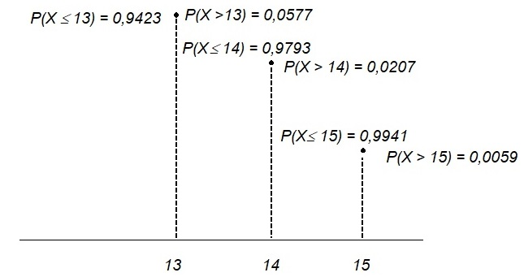

By the definition of the **critical area** and as far as $14$ is the smallest number such that $P(X > 14) \leq \alpha$ the **critical area** is
$$W_\alpha = \{X > 14\}$$

If we have $15$ or more tails we can reject $H_0$ and we can say that the tails are more favourable than the heads. The coin will be biased in favour of tails.

By the condition of the task we have $13$ tails. So, the sample does not belong to the critical area for $H_0$ and we cannot reject $H_0$. We can’t say the coin is biased in favour of tails.

We can make the same by

```r
> binom.test (13, 20, p = 0.5, alternative = "greater")

    Exact binomial test

data:  13 and 20
number of successes = 13, number of trials = 20, p-value = 0.1316
alternative hypothesis: true probability of success is greater than 0.5
95 percent confidence interval:
 0.4419655 1.0000000
sample estimates:
probability of success
                  0.65
```

or

```r
> prop.test (13, 20, p = 0.5, alternative = "greater")

    1-sample proportions test with continuity correction

data:  13 out of 20, null probability 0.5
X-squared = 1.25, df = 1, p-value = 0.1318
alternative hypothesis: true p is greater than 0.5
95 percent confidence interval:
 0.4423272 1.0000000
sample estimates:
   p
0.65
```

Now let’s solve the task if the alternative is “The coin is biased”. In this case we have to use **two-tailed test**.

Again let $X$ be the number of tails and $p$ be the probability of the event “to have a tail” on the observed coin.

Then, $X \in Bi(20, p)$.

$H_0: p = \frac{1}{2}$. The coin is symmetric.

$H_A: p \neq \frac{1}{2}$. The coin is biased.

We chose $\alpha = 0.05$ and have to determine the **critical area** for $H_0$ in such a way that

$$P(To \: reject \: H_0|H_0) \leq \alpha.$$

We need to compute the the largest $b_{\frac{\alpha}{2}}$ and the smallest $b_{1-\frac{\alpha}{2}}$ such that

$$P(X < b_{\frac{\alpha}{2}} \cup X > b_{1-\frac{\alpha}{2}}|H_0) \leq \alpha$$
By the definition of the quantiles $b_{\frac{\alpha}{2}}$ is the smallest number such that $P(X \leq b_{\frac{\alpha}{2}}) \geq \frac{\alpha}{2}$.

Analogously $b_{1 - \frac{\alpha}{2}}$ is the smallest number such that $P(X \leq b_{1 - \frac{\alpha}{2}}) \geq 1 - \frac{\alpha}{2}$.

```r
> qbinom(alpha / 2, 20, 1/2)
[1] 6
> qbinom(1 - alpha/2, 20, 1/2)
[1] 14
> pbinom(6, 20, 1/2)
[1] 0.05765915
> pbinom(5, 20, 1/2)
[1] 0.02069473
> pbinom(7, 20, 1/2)
[1] 0.131588
> pbinom(14, 20, 1/2)
[1] 0.9793053
> pbinom(13, 20, 1/2)
[1] 0.9423409
> pbinom(15, 20, 1/2)
[1] 0.994091
> pbinom(14, 20, 1/2, lower.tail = FALSE)
[1] 0.02069473
> pbinom(13, 20, 1/2, lower.tail = FALSE)
[1] 0.05765915
> pbinom(15, 20, 1/2, lower.tail = FALSE)
[1] 0.005908966
> pValue <- pbinom(7, 20, 1/2) + pbinom(12, 20, 1/2, lower.tail = FALSE)
> pValue
[1] 0.263176
```

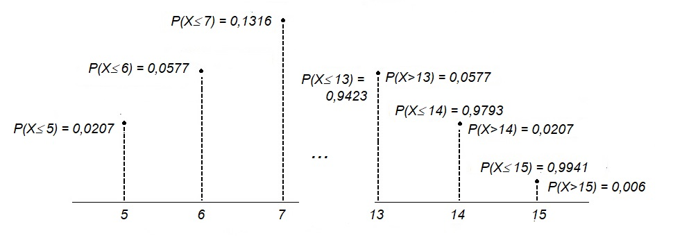

By the definition of the **critical area** and as far as the largest number such that $P(X < 6) \leq \frac{\alpha}{2}$ is $6$, and the smallest number such that $P(X > 14) \leq \frac{\alpha}{2}$ is $14$, the **critical area** is
$$W_\alpha = \{X < 6\: or\: X > 14\}.$$
Then if the tails are $< 6$ or $> 14$ we reject $H_0$ and conclude that the coin is not fair.

However by the condition of the task we have $13$ tails. So, the sample does not belong to the critical area for $H_0$ and we cannot reject $H_0$. We cannot conclude that the coin is not fair.

We can make the same by

```r
> binom.test (13, 20, p = 0.5)

    Exact binomial test

data:  13 and 20
number of successes = 13, number of trials = 20, p-value = 0.2632
alternative hypothesis: true probability of success is not equal to 0.5
95 percent confidence interval:
 0.4078115 0.8460908
sample estimates:
probability of success
                  0.65
```

or

```r
> prop.test(13, 20, p = 0.5)

    1-sample proportions test with continuity correction

data:  13 out of 20, null probability 0.5
X-squared = 1.25, df = 1, p-value = 0.2636
alternative hypothesis: true p is not equal to 0.5
95 percent confidence interval:
 0.4094896 0.8369133
sample estimates:
   p
0.65
```

The $p-value = 0.2636 > 0.05 = \alpha$, so the sample is not in the critical area for $H_0$ and we can’t reject $H_0$. So we have no evidence to say that the coin is not symmetric.

### Example 2:

Suppose you have a die and suspect that it is biased towards the number six. We throw the die $25$ times and count that the number six comes up $7$ times. Perform a hypothesis test at a $5\%$ significance level to see whether the die is biased and six is more favourable.

Let us denote by $X$ the number of sixes and by $p$ the probability of the event “to have six points” on the observed die.

Then on this die $X \in Bi(25, p)$.

$H_0: p = \frac{1}{6}$. The die is not biased.

$H_A: p > \frac{1}{6}$. The die is biased in favour of six points.

We need a **one-tailed test** as the alternative hypothesis says “in favour of six points”.

We have $\alpha = 0.05$ and have to determine the critical area for $H_0$ in such a way that

$$P(To \: reject \: H_0|H_0) \leq \alpha.$$

We need to compute the lagrest $b_{1-\alpha}$ such that

$$P(X > b_{1-\alpha}|H_0) \leq 0.05$$
By the definition of the quantiles it is the smallest number such that $P(X \leq b_{1-\alpha}) \geq 1-\alpha$.

```r
> alpha <- 0.05
> qbinom(1 - alpha, 25, 1/6)
[1] 7
> pbinom(7, 25, 1/6)
[1] 0.9552681
> pbinom(6, 25, 1/6)
[1] 0.8907691
> pbinom(8, 25, 1/6)
[1] 0.9842926
> pbinom(7, 25, 1/6, lower.tail = FALSE)
[1] 0.04473193
> pbinom(6, 25, 1/6, lower.tail = FALSE)
[1] 0.1092309
> pbinom(8, 25, 1/6, lower.tail = FALSE)
[1] 0.01570738
> pValue <- pbinom(6, 25, 1/6, lower.tail = FALSE)
> pValue
[1] 0.1092309
```

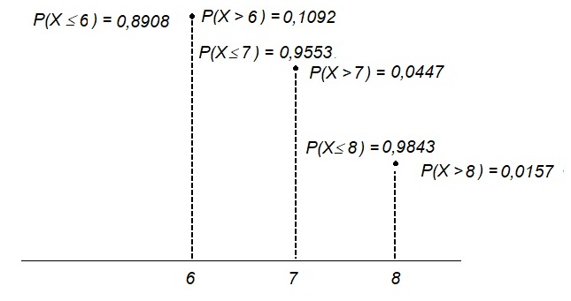

By the definition of the critical area and as far as $7$ is the smallest number such that $P(X > 7) \leq \alpha$, the critical area is
$$W_\alpha = \{X > 7\}$$

If we have more than $7$ sixes we can reject $H_0$ and we can say that the six is more favourable than the others. The die is biased in favour of six.

However in our case we have exactly $7$ sixes, therefore, the sample is not in the critical area for $H_0$ and we cannot reject $H_0$. We cannot conclude that the die is not fair.

We can make the same by

```r
> binom.test (7, 25, p = 1/6, alternative = "greater")

    Exact binomial test

data:  7 and 25
number of successes = 7, number of trials = 25, p-value = 0.1092
alternative hypothesis: true probability of success is greater than 0.1666667
95 percent confidence interval:
 0.1394753 1.0000000
sample estimates:
probability of success
                  0.28
```

A two-tailed test would be the result of an alternative hypothesis saying “The die is biased”.

Again let $X$ be the number of six and $p$ be the probability of the event “to have six points” on this die.

Then, $X \in Bi(25, p)$ on this die.

$H_0: p = \frac{1}{6}$. The die is not biased.

$H_A: p \neq \frac{1}{6}$. The die is biased.

We chose $\alpha = 0.05$ and have to determine the critical area for $H_0$ in such a way that

$$P(To \: reject \: H_0|H_0) \leq \alpha.$$

We need to compute the largest $b_{\frac{\alpha}{2}}$ and the smallest $b_{1-\frac{\alpha}{2}}$ such that

$$P(X < b_{\frac{\alpha}{2}} \cup X > b_{1-\frac{\alpha}{2}}|H_0) \leq \alpha$$

By the definition of the quantiles $b_{\frac{\alpha}{2}}$ is the smallest number such that $P(X \leq b_{\frac{\alpha}{2}}) \geq \frac{\alpha}{2}$.

Analogously $b_{1 - \frac{\alpha}{2}}$ is the smallest number such that $P(X \leq b_{1 - \frac{\alpha}{2}}) \geq 1 - \frac{\alpha}{2}$.

```r
> qbinom(alpha/2, 25, 1/6)
[1] 1
> qbinom(1 - alpha/2, 25, 1/6)
[1] 8
> pbinom(0, 25, 1/6)
[1] 0.0104826
> pbinom(1, 25, 1/6)
[1] 0.06289558
> pbinom(2, 25, 1/6)
[1] 0.1886867
> pbinom(8, 25, 1/6)
[1] 0.9842926
> pbinom(7, 25, 1/6)
[1] 0.9552681
> pbinom(9, 25, 1/6)
[1] 0.9952574
> pbinom(8, 25, 1/6, lower.tail = FALSE)
[1] 0.01570738
> pbinom(7, 25, 1/6, lower.tail = FALSE)
[1] 0.04473193
> pbinom(9, 25, 1/6, lower.tail = FALSE)
[1] 0.004742551
> pValue <- pbinom(1, 25, 1/6) + pbinom(6, 25, 1/6, lower.tail = FALSE)
> pValue
[1] 0.1721265
```

[figure not shown]

By the definition of the critical area and as far as the largest number such that $P(X < 1) \leq \frac{\alpha}{2}$ is $1$, and the smallest number such that $P(X > 8) \leq \frac{\alpha}{2}$ is $8$, the critical area is not symmetric
$$W_\alpha = \{X < 1\: or\: X > 8\}.$$

Then if the six are $0$ or $> 8$ we reject $H_0$. By condition the number six comes up $7$ times. So, we cannot reject $H_0$.

We can make the same by

```r
> binom.test (7, 25, p = 1/6)

    Exact binomial test

data:  7 and 25
number of successes = 7, number of trials = 25, p-value = 0.1721
alternative hypothesis: true probability of success is not equal to 0.1666667
95 percent confidence interval:
 0.1207167 0.4938768
sample estimates:
probability of success
                  0.28
```

```r
> prop.test(7, 25, p = 1/6)
Warning in prop.test(7, 25, p = 1/6): Chi-squared approximation may be incorrect

    1-sample proportions test with continuity correction

data:  7 out of 25, null probability 1/6
X-squared = 1.568, df = 1, p-value = 0.2105
alternative hypothesis: true p is not equal to 0.1666667
95 percent confidence interval:
 0.1287239 0.4959901
sample estimates:
   p
0.28
```

The $p-value = 0.2105 > 0.05 = \alpha$, therefore the sample is not in the critical area for $H_0$ and we assume $H_0$, so the die isn’t biased.

Note: For different $\alpha$ it is possible to obtain contradictions. A possible solution of the problem is to increase the sample and to perform analogous hypothesis testing again. Toss a die $30$ times and test the same hypothesis.

### Example 3:

You ask $100$ people in a survey and $42$ say “yes” to your question. Does this support the hypothesis that the true proportion is $50\%$?

In this case $X \in Bi(100, p)$.

To answer this, we set up a **two-sided hypothesis test**. The **null hypothesis** is

$H_0: p = 0.5$

and the **alternative hypothesis** is

$H_A: p \neq 0.5$

We can use the `binom.test` function

```r
> binom.test(42, 100, p = 0.5)

    Exact binomial test

data:  42 and 100
number of successes = 42, number of trials = 100, p-value = 0.1332
alternative hypothesis: true probability of success is not equal to 0.5
95 percent confidence interval:
 0.3219855 0.5228808
sample estimates:
probability of success
                  0.42
```

or `prop.test` function

```r
> prop.test(42, 100, p = 0.5)

    1-sample proportions test with continuity correction

data:  42 out of 100, null probability 0.5
X-squared = 2.25, df = 1, p-value = 0.1336
alternative hypothesis: true p is not equal to 0.5
95 percent confidence interval:
 0.3233236 0.5228954
sample estimates:
   p
0.42
```

The $p-value$ reports how likely is to see this data or worse assuming the null hypothesis. In particular $p-value$ is the probability of $42$ or fewer or $58$ or more answer “yes” when the chance a person will answer “yes” is fifty-fifty. The $p-value = 0.1336 > 0.05 = \alpha$ is not so small as to make an observation of $42$ seem unreasonable in $100$ samples assuming the $H_0$. So the sample is not in the critical part for the null hypothesis and we **don’t have reason to reject the null hypothesis**.

Let’s repeat the survey, but this time suppose we are asking $1000$ people and $420$ say yes. Does this support the hypothesis that the true proportion is $50\%$?

This time the hypothesis look the same.

$$H_0: p = 0.5$$

$$H_A: p \neq 0.5$$

```r
> binom.test(420, 1000, p = 0.5)

    Exact binomial test

data:  420 and 1000
number of successes = 420, number of trials = 1000, p-value = 4.697e-07
alternative hypothesis: true probability of success is not equal to 0.5
95 percent confidence interval:
 0.3891836 0.4512888
sample estimates:
probability of success
                  0.42
```

```r
> prop.test(420, 1000, p = 0.5)

    1-sample proportions test with continuity correction

data:  420 out of 1000, null probability 0.5
X-squared = 25.281, df = 1, p-value = 4.956e-07
alternative hypothesis: true p is not equal to 0.5
95 percent confidence interval:
 0.3892796 0.4513427
sample estimates:
   p
0.42
```

Now the $p-value = 4.956e-07 < 0.05 = \alpha$ and the **null hypothesis is not supported**. The sample is in the critical area for the null hypothesis and we reject $H_0$.

These to examples show that when the sample size is smaller the accuracy is smaller and, therefore, bigger differences between the tested and empirical value are not statistically significant. When the sample size increases the accuracy increases and smaller differences between the test and empirical value can be statistically significant.

## Hypothesis testing for equality between the populational mean and a constant

**Case 1.** If $X \in N(\mu, \sigma^2)$, where $\mu = \mathbb{E}X$ and $\sigma^2$ is known.

$H_0 : \mu = \mu_0$, where $\mu_0 = const$. The last means that the differences between the average of the sample and $\mu_0$ is not statistically significant.

$H_A$ could be formulated in one of the following ways.

$\checkmark$ $H_A$ : $\mu < \mu_0$,

In this case later on we speak about **left-sided critical area**.

$\checkmark$ $H_A$ : $\mu > \mu_0$,

In this case later on we speak about **right-sided critical area**.

$\checkmark$ $H_A$ : $\mu \neq \mu_0$.

In this case later on we speak about **two-sided critical area**.

Although $H_0$ is for equality, when we analyze the result we explain it as the opposite of $H_A$.

We chose **type I error**
$$P(To \: reject \: H_0|H_0) \leq \alpha.$$

**The critical area for $H_0$** is

$\checkmark$ In case of **left-sided**

$$W_\alpha = \left\{\frac{\bar{X}_n - \mu_0}{\frac{\sigma}{\sqrt{n}}} \leq z_{\alpha, N(0, 1)}\right\}.$$

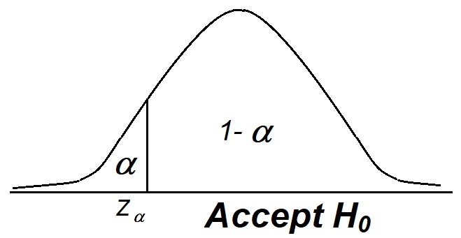

When we compute $z_{emp} = \frac{\bar{X}_n - \mu_0}{\frac{\sigma}{\sqrt{n}}}$ from the data we can compare $z_{emp}$ with $z_{\alpha, N(0, 1)}$. If $z_{emp} > z_{\alpha, N(0, 1)}$ then the sample does not belong to the critical area of $H_0$ and there is no reason to reject $H_0$. In this case we assume $H_0$. Conversely if $z_{emp} \leq z_{\alpha, N(0, 1)}$, then the sample is in the critical area of $H_0$. In this case we reject $H_0$ and assume $H_A$. The mean of the observed random variable $X$, i.e. $\mathbb{E}X$ is statistically significant less than $\mu_0$.

$$p-value = \mathbb{P}\left(\eta \leq z_{emp}\right), \quad \eta \in N(0, 1).$$

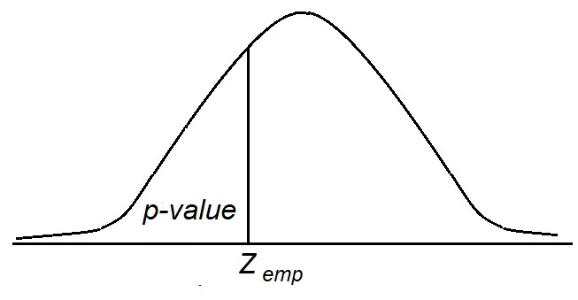

### Example 5:

Let us assume that a car gets $X \in N(\mu, 4)$ mpg. A manufacturer claims $\mu_0 = 25$ mpg. A consumer group asks $10$ owners of this model to calculate their mpg and the mean value was $22$ mpg. Is the manufacturer’s claim supported? Check the hypothesis for significance level $0.05$.

In this case we can have **one-sided hypothesis test**

$H_0: \mu = 25$ - The manufacturer’s claim cannot be rejected.

$H_A: \mu < 25$ - The manufacturer’s claim can be rejected.

The data are summarized and we have the average. So,

```r
> xbar <- 22; sigma <- 2; n <- 10
> zemp <- (xbar - 25) / (sigma / sqrt(n)); zemp
[1] -4.743416
```

First way to solve this is to **compare the empirical value with the critical value** $z_{\alpha, N(0, 1)}$.

```r
> alpha <- 0.05
> zcritical <- qnorm(alpha); zcritical
[1] -1.644854
```

The empirical value $-4.743416$ is less than $z_{0.05, N(0, 1)} = -1.644854$. Therefore the sample is **in the critical area for the null hypothesis** and we **reject $H_0$**. The manufacturer’s claim is suspicious.

Second way to solve this is to compute the $p-value$ and to compare it with $\alpha$.

```r
> pnorm(zemp, 0, 1)
[1] 1.050718e-06
```

The $p-value < 0.05 = \alpha$. The sample is in the critical area for the null hypothesis and we reject $H_0$. The manufacturer’s claim is suspicious.

$\checkmark$ In case of **right-sided critical area**.

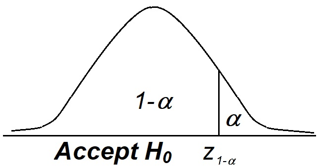

$$W_\alpha = \left\{\frac{\bar{X}_n - \mu_0}{\frac{\sigma}{\sqrt{n}}} \geq z_{1 - \alpha, N(0, 1)}\right\}.$$
When we compute $z_{emp} = \frac{\bar{X}_n - \mu_0}{\frac{\sigma}{\sqrt{n}}}$ from the data we can compare $z_{emp}$ with $z_{1-\alpha, N(0, 1)}$. If $z_{emp} < z_{1-\alpha, N(0, 1)}$, then the sample does not belong to the critical area of $H_0$ and there is no reason to reject $H_0$. In this case we assume $H_0$. Conversely if $z_{emp} \geq z_{1-\alpha, N(0, 1)}$, then the sample is in the critical area of $H_0$. In this case we reject $H_0$ and assume $H_A$. The mean of the observed random variable $\mathbb{E}X$ is statistically significantly bigger than $\mu_0$.

$$p-value = \mathbb{P}\left(\eta \geq z_{emp}\right), \quad \eta \in N(0, 1).$$

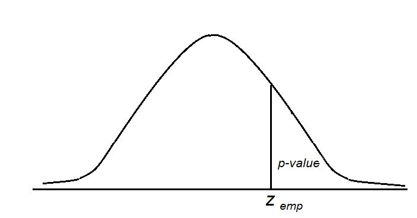

If $p-value > \alpha$, then the sample does not belong to the critical area of $H_0$ and there is no reason to reject $H_0$. In this case we assume $H_0$. Conversely if $p-value < \alpha$, then the sample is in the critical area of $H_0$. In this case we reject $H_0$ and assume $H_A$. The mean of the observed random variable $\mathbb{E}X$ is statistically significantly bigger than $\mu_0$.

### Example 6:

Let us assume that the standard weight of a mushroom is at most $40$ grams and it is $X \in N(\mu, 9)$. A customer claims that the mushrooms of a producer are not standard. The producer chooses $15$ mushrooms at random and weighs them. The average of the mushrooms was $41$ grams. Can the customer’s claim be rejected?

In this case we can have **right-sided hypothesis test**

$H_0: \mu = 40$ - The customer’s claim can be rejected.

$H_A: \mu > 40$ - The customer’s claim can not be rejected.

The data are summarized and we have the average. So,

```r
> xbar <- 41; sigma <- 3; n <- 15
> zemp <- (xbar - 40) / (sigma / sqrt(n)); zemp
[1] 1.290994
```

First way to solve this is to compare the empirical value with the critical value $z_{1 - \alpha, N(0, 1)}$.

```r
> alpha <- 0.05
> zcritical <- qnorm(1 - alpha); zcritical
[1] 1.644854
```

Second way to solve this is to compute the $p-value$ and to compare it with $\alpha$.

```r
> pnorm(zemp, 0, 1, lower.tail = FALSE)
[1] 0.0983528
```

$\checkmark$ In case of **two-sided critical area**.

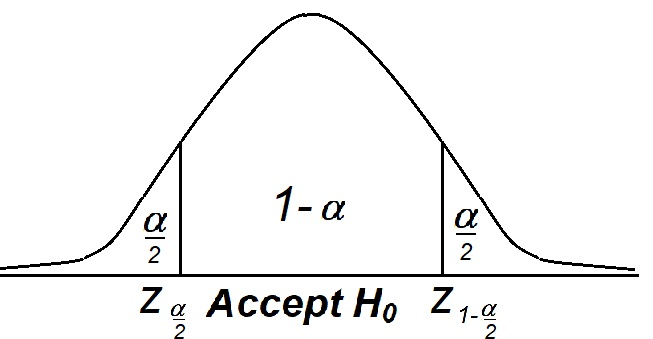

$$W_\alpha = \left\{\frac{|\bar{X}_n - \mu_0|}{\frac{\sigma}{\sqrt{n}}} \geq z_{1 - \frac{\alpha}{2}, N(0, 1)}\right\}.$$
When we compute $z_{emp} = \frac{|\bar{X}_n - \mu_0|}{\frac{\sigma}{\sqrt{n}}}$ from the data we can compare $z_{emp}$ with $z_{1-\frac{\alpha}{2}, N(0, 1)}$ and $- z_{1-\frac{\alpha}{2}, N(0, 1)}$.

If $-z_{1-\frac{\alpha}{2}, N(0, 1)}< z_{emp} < z_{1-\frac{\alpha}{2}, N(0, 1)}$, then the sample does not belong to the critical area of $H_0$ and there is no reason to reject $H_0$. In this case we assume $H_0$. Conversely if $z_{emp}\leq -z_{1-\frac{\alpha}{2}, N(0, 1)}$ or $z_{1-\frac{\alpha}{2}, N(0, 1)} \leq z_{emp}$, then the sample is in the critical area of $H_0$. In this case we reject $H_0$. The mean of the observed random variable $\mathbb{E}X$ is statistically significantly different from $\mu_0$.

$$p-value = \mathbb{P}\left(|\eta| \geq z_{emp}\right) = \mathbb{P}\left(\eta \leq -z_{emp} \: \cup \:\eta \geq z_{emp}\right), \quad \eta \in N(0, 1).$$

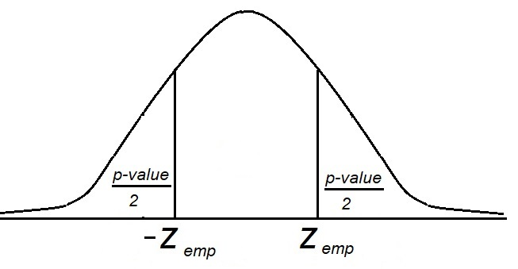

If $p-value > \alpha$, then the sample does not belong to the critical area of $H_0$ and there is no reason to reject $H_0$. In this case we assume $H_0$. Conversely if $p-value < \alpha$, then the sample is in the critical area of $H_0$. In this case we reject $H_0$ and assume $H_A$. The mean of the observed random variable $\mathbb{E}X$ is statistically significantly different from $\mu_0$.

### Example 7:

Let us assume that the standard weight of a mushroom is $40$ grams and it is $X \in N(\mu, 9)$. A customer claims that the mushrooms of a producer are not standard. The producer chooses $15$ mushrooms at random and weighs them. The average of the mushrooms was $41$ grams. Can the customer’s claim be rejected?

In this case we can have **two-sided hypothesis test**

$H_0: \mu = 40$ - The customer’s claim can be rejected.

$H_A: \mu \neq 40$ - The customer’s claim can not be rejected.

The data are summarized and we have the average. So,

```r
> xbar <- 41; sigma <- 3; n <- 15
> zemp <- abs(xbar - 40) / (sigma / sqrt(n)); zemp
[1] 1.290994
```

First way to solve this is to compare the empirical value with the critical values $-z_{1 - \frac{\alpha}{2}, N(0, 1)}$ and $z_{1 - \frac{\alpha}{2}, N(0, 1)}$ .

```r
> zcritical1<- -qnorm(1 - alpha/2); zcritical1
[1] -1.959964
> zcritical2<- qnorm(1 - alpha/2); zcritical2
[1] 1.959964
```

The empirical value is $1.290994$ in the interval between $-z_{1 - \frac{0.05}{2}, N(0, 1)} = -z_{0.975, N(0, 1)} = -1.959964$ and $z_{0.975, N(0, 1)} = 1.959964$. Therefore, the sample is **not in the critical area for the null hypothesis** and we have **no reason to reject $H_0$**. The customer’s claim can be rejected.

Second way to solve this is to compute the $p-value$ and to compare it with $\alpha$.

```r
> 2*pnorm(zemp, 0, 1,lower.tail = FALSE)
[1] 0.1967056
```

The $p-value = 0.1967 > 0.05 = \alpha$. The sample is in not the critical area for the null hypothesis and we have no reason to reject $H_0$. The difference between $41$ and $40$ is not statistically significant. The customer’s claim can be rejected.

**Case 2.** If the observed random variable $X \in N(\mu, \sigma^2)$ and $\sigma^2$ is **unknown**

In this case we estimate $\sigma^2$ by its unbiased estimate $s^2$ from the sample and replace $N(0, 1)$ with $t(n-1)$.

As far as when the degrees of freedom of $t$ distribution are at least $30$ it almost coincides with $N(0, 1)$ distribution the results from the next approach is different from the previous one only when the sample size $n \leq 30$.

The tested hypothesis are the analogous as in the previous case.

The critical areas for $H_0$ are as follows:

$\checkmark$ If the critical area is **left-sided**

$$W_\alpha = \left\{\frac{\bar{X}_n - \mu_0}{\frac{s}{\sqrt{n}}} \leq t_{\alpha, t(n - 1)}\right\},$$

where $t_{\alpha, t(n - 1)}$ is the $\alpha$ quantile of $t(n-1)$ distribution.

When we compute $t_{emp} = \frac{\bar{X}_n - \mu_0}{\frac{s}{\sqrt{n}}}$ from the data we can compare $t_{emp}$ with $t_{\alpha, t(n-1)}$. If $t_{emp} > t_{\alpha, t(n-1)}$ then the sample does not belong to the critical area of $H_0$ and there is no reason to reject $H_0$. In this case we assume $H_0$. Conversely if $t_{emp} \leq t_{\alpha, t(n-1)}$, then the sample is in the critical area of $H_0$. In this case we reject $H_0$ and assume $H_A$. The mean of the observed random variable $\mathbb{E}X$ is statistically significantly less than $\mu_0$.

$$p-value = \mathbb{P}\left(\eta \leq t_{emp}\right), \quad \eta \in t(n-1).$$

If $p-value > \alpha$, then the sample does not belong to the critical area of $H_0$ and there is no reason to reject $H_0$. In this case we assume $H_0$. Conversely if $p-value < \alpha$, then the sample is in the critical area of $H_0$. In this case we reject $H_0$. The mean of the observed random variable $\mathbb{E}X$ is statistically significantly less than $\mu_0$.

### Example 8:

Let us assume that a car gets $X \in N(\mu, \sigma^2)$. A manufacturer claims $\mu_0 = 25$ mpg. A consumer group asks $10$ owners of this model to calculate their mpg. The mean value in the sample was $22$ mpg. and the standard deviation in the sample was $3$ mpg. Is the manufacturer’s claim supported?

In this case we can have **one-sided hypothesis test**

$H_0: \mu = 25$ - The manufacturer’s claim can not be rejected.

$H_A: \mu < 25$ - The manufacturer’s claim can be rejected.

The data are summarized and we have the average. So,

```r
> xbar <- 22; s <- 3; n <- 10
> temp <- (xbar - 25) / (s / sqrt(n)); temp
[1] -3.162278
> alpha <- 0.05
> tcritical <- qt(alpha, n - 1); tcritical
[1] -1.833113
```

```r
> pt(temp, n-1)
[1] 0.005753993
```

The $p-value = 0.005753993 < 0.05 = \alpha$. The sample is in the critical area for the null hypothesis and we reject $H_0$. The manufacturer’s claim is suspicious.

$\checkmark$ If the critical area is **right-sided**

$$W_\alpha = \left\{\frac{\bar{X}_n - \mu_0}{\frac{s}{\sqrt{n}}} \geq t_{1 - \alpha, t(n-1)}\right\}.$$
When we compute $t_{emp} = \frac{\bar{X}_n - \mu_0}{\frac{s}{\sqrt{n}}}$ from the data we can compare $t_{emp}$ with $t_{1-\alpha, t(n-1)}$. If $t_{emp} < t_{1-\alpha, t(n-1)}$, then the sample does not belong to the critical area of $H_0$ and there is no reason to reject $H_0$. In this case we assume $H_0$. Conversely if $t_{emp} \geq t_{1-\alpha, t(n-1)}$, then the sample is in the critical area of $H_0$. In this case we reject $H_0$ and assume $H_A$. The mean of the observed random variable $\mathbb{E}X$ is statistically significantly bigger than $\mu_0$.

$$p-value = \mathbb{P}\left(\eta \geq t_{emp}\right), \quad \eta \in t(n-1).$$

If $p-value > \alpha$, then the sample does not belong to the critical area of $H_0$ and there is no reason to reject $H_0$. In this case we assume $H_0$. Conversely if $p-value < \alpha$, then the sample is in the critical area of $H_0$. In this case we reject $H_0$. The mean of the observed random variable $\mathbb{E}X$ is statistically significantly bigger than $\mu_0$.